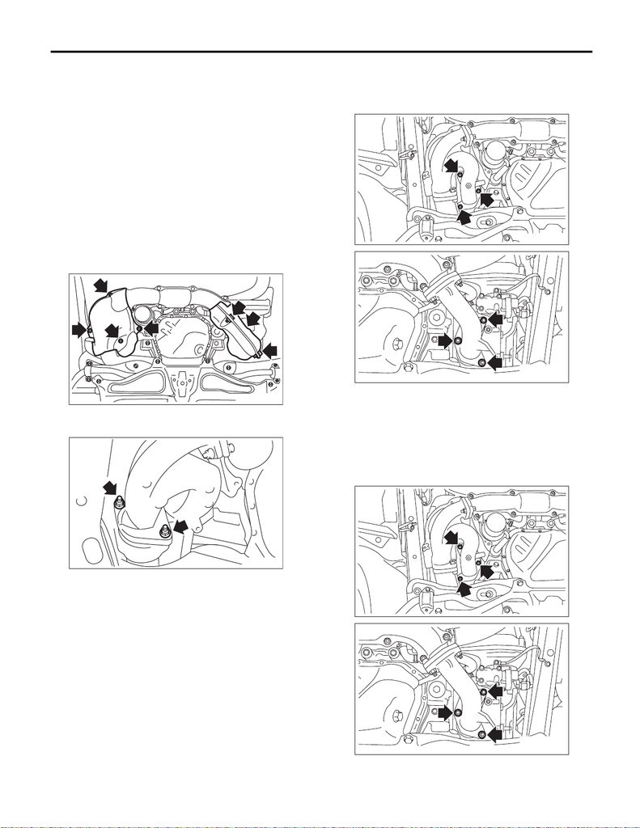

EX(STI)-5

Front Exhaust Pipe

EXHAUST

2. Front Exhaust Pipe

A: REMOVAL

CAUTION:

Vehicle components are extremely hot after

driving. Be wary of receiving burns from heated

parts.

1) Disconnect the ground cable from battery.

2) Lift up the vehicle.

3) Remove the under cover. <Ref. to EI-21, RE-

MOVAL, Front Under Cover.>

4) Remove the front oxygen (A/F) sensor. <Ref. to

FU(STI)-52, REMOVAL, Front Oxygen (A/F) Sen-

sor.>

5) Remove the exhaust manifold RH lower cover

and exhaust manifold LH cover.

6) Remove the bolts and nuts which hold joint pipe

onto exhaust manifold RH.

7) While holding the front exhaust pipe with one

hand, remove the nuts which hold the exhaust

manifold to the cylinder head exhaust port and re-

move the front exhaust pipe.

B: INSTALLATION

1) Install the front exhaust pipe.

NOTE:

Use a new gasket.

Tightening torque:

40 N·m (4.1 kgf-m, 29.5 ft-lb)

EX-02253

EX-00018

EX-03134

EX-03135

EX-03134

EX-03135

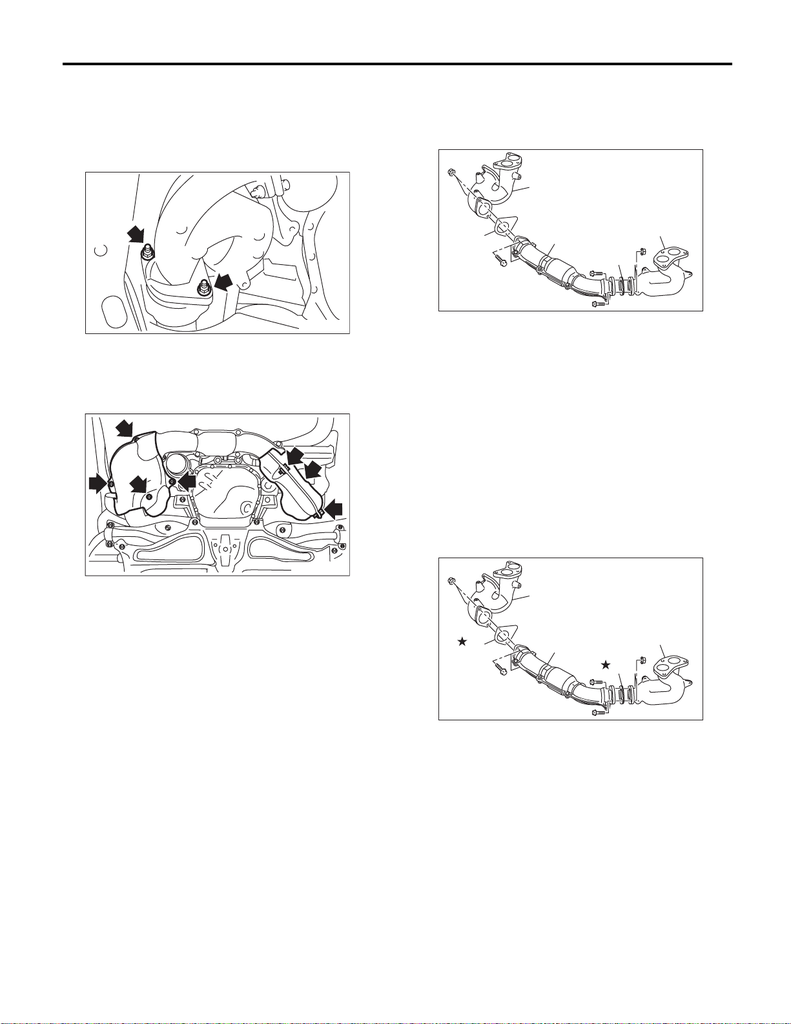

EX(STI)-6

Front Exhaust Pipe

EXHAUST

2) Install the joint pipe to the exhaust manifold RH.

NOTE:

Use a new gasket.

Tightening torque:

42.5 N·m (4.3 kgf-m, 31.3 ft-lb)

3) Install the exhaust manifold RH lower cover and

exhaust manifold LH cover.

Tightening torque:

19 N·m (1.9 kgf-m, 14.0 ft-lb)

4) Install the front oxygen (A/F) sensor. <Ref. to

FU(STI)-52, INSTALLATION, Front Oxygen (A/F)

Sensor.>

5) Install the under cover. <Ref. to EI-22, INSTAL-

LATION, Front Under Cover.>

6) Lower the vehicle.

7) Connect the battery ground terminal.

C: DISASSEMBLY

1) Remove the exhaust manifold RH upper cover.

2) Remove the exhaust manifold RH and the ex-

haust manifold LH from the front exhaust pipe.

D: ASSEMBLY

1) Install the exhaust manifold RH and the exhaust

manifold LH to the front exhaust pipe.

NOTE:

Use a new gasket.

Tightening torque:

42.5 N·m (4.3 kgf-m, 31.3 ft-lb)

2) Install the exhaust manifold RH upper cover.

Tightening torque:

19 N·m (1.9 kgf-m, 14.0 ft-lb)

E: INSPECTION

1) Check the connections and welds for exhaust

leaks.

2) Make sure there are no holes or rusting.

EX-00018

EX-02253

(A) Front exhaust pipe

(B) Exhaust manifold RH

(C) Exhaust manifold LH

(D) Gasket

(E) Gasket

(A) Front exhaust pipe

(B) Exhaust manifold RH

(C) Exhaust manifold LH

(D) Gasket

(E) Gasket

EX-02729

(D)

(A)

(B)

(C)

(E)

EX-02730

(D)

(A)

(B)

(C)

(E)